# Problem Set 2

Patrick Altmeyer, Buelent Uendes, Antonios Vasileiadis

11 March, 2021

# 1.)

Check whether the networks in Figures 14.19, 14.20, and 14.21 in Easley, Kleinberg, and others (2010), ch. 14, are strongly connected and aperiodic. For the ones that satisfy both properties, find the PageRank equilibrium values of all nodes (without the use of a computer; explain the steps you follow).

Let $\mathbf{T}$ denote the transition matrix. If the network is

- strongly connected: $\exists$ a path connecting $i \rightarrow j$ for all $i,j\in N$
- aperiodic: greatest common divisor (of the lengths of cycles) is equal to 1

then there exists an equilibrium formulation of PageRank:

$$\begin{equation}
\begin{aligned}
&& \mathbf{r}&=\mathbf{T}^T\mathbf{r}, & \mathbf{r}^T\mathbf{1}=1 \\
\end{aligned}
\tag{1}
\end{equation}$$

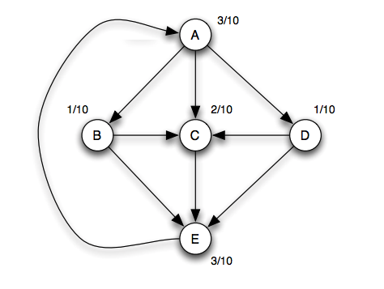

Figure 1: Network 14.19 in Easley, Kleinberg, and others (2010).

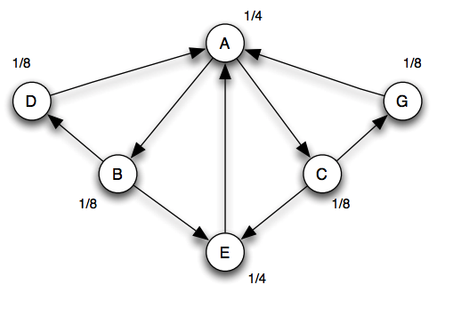

Figure 2: Network 14.20 in Easley, Kleinberg, and others (2010).

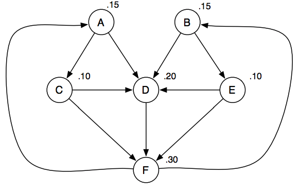

Figure 3: Network 14.21 in Easley, Kleinberg, and others (2010).

Now we are asked to derive the steady-state PageRank by hand. To do so we can simply solve the system of equations defined in (1) each time.

For the network in Figure (1), the corresponding transition matrix is:

$$\begin{equation}
\begin{aligned}
&& \mathbf{T}&=\begin{bmatrix} 0 & 0.3333333 & 0.3333333 & 0.3333333 & 0 \\ 0 & 0 & 0.5 & 0 & 0.5 \\ 0 & 0 & 0 & 0 & 1 \\ 0 & 0 & 0.5 & 0 & 0.5 \\ 1 & 0 & 0 & 0 & 0 \\ \end{bmatrix} \\
\end{aligned}
\tag{2}
\end{equation}$$

We can then solve $\mathbf{T}^T\mathbf{r}$ as follows:

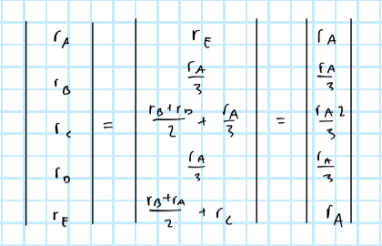

Figure 4: Derivation of steady-state of network 14.19 in Easley, Kleinberg, and others (2010).

Noting that we need to have $(\mathbf{T}^T\mathbf{r})^T\mathbf{1}=1$ we have for the steady-state PageRank vector: $\mathbf{r}^T=\frac{1}{10}(3,1,2,1,3)$, where the first entry corresponds to node $A$ and the last to node $E$.

Similarly for the network in Figure (2) we have

$$\begin{equation}
\begin{aligned}
&& \mathbf{T}&=\begin{bmatrix} 0 & 0.5 & 0.5 & 0 & 0 & 0 \\ 0 & 0 & 0 & 0.5 & 0.5 & 0 \\ 0 & 0 & 0 & 0 & 0.5 & 0.5 \\ 1 & 0 & 0 & 0 & 0 & 0 \\ 1 & 0 & 0 & 0 & 0 & 0 \\ 1 & 0 & 0 & 0 & 0 & 0 \\ \end{bmatrix} \\
\end{aligned}
\tag{3}
\end{equation}$$

which solves to

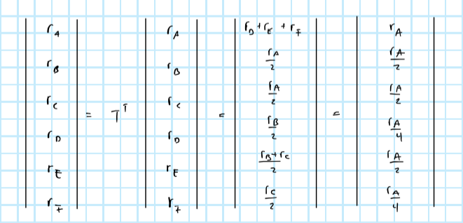

Figure 5: Derivation of steady-state of network 14.20 in Easley, Kleinberg, and others (2010).

$$\begin{equation}
\begin{aligned}
&& \mathbf{T}&=\begin{bmatrix} 0 & 0 & 0.5 & 0.5 & 0 & 0 \\ 0 & 0 & 0 & 0.5 & 0.5 & 0 \\ 0 & 0 & 0 & 0.5 & 0 & 0.5 \\ 0 & 0 & 0 & 0 & 0 & 1 \\ 0 & 0 & 0 & 0.5 & 0 & 0.5 \\ 0.5 & 0.5 & 0 & 0 & 0 & 0 \\ \end{bmatrix} \\
\end{aligned}
\tag{4}
\end{equation}$$

which solves to

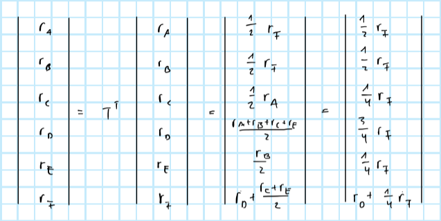

Figure 6: Derivation of steady-state of network 14.21 in Easley, Kleinberg, and others (2010).

# 2.)

## i)

Find all the maximal cliques in the following network. Explain how can you find this list without making use of a computer.

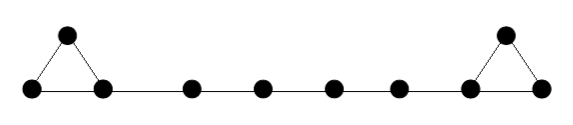

Figure 7: Networks.

Just looking at the network in Figure (7) it is clear that there are two cliques, one at the far left and one at the far right end, both of size 3.

# 4.)

## a)

By hand this can be done as follows:

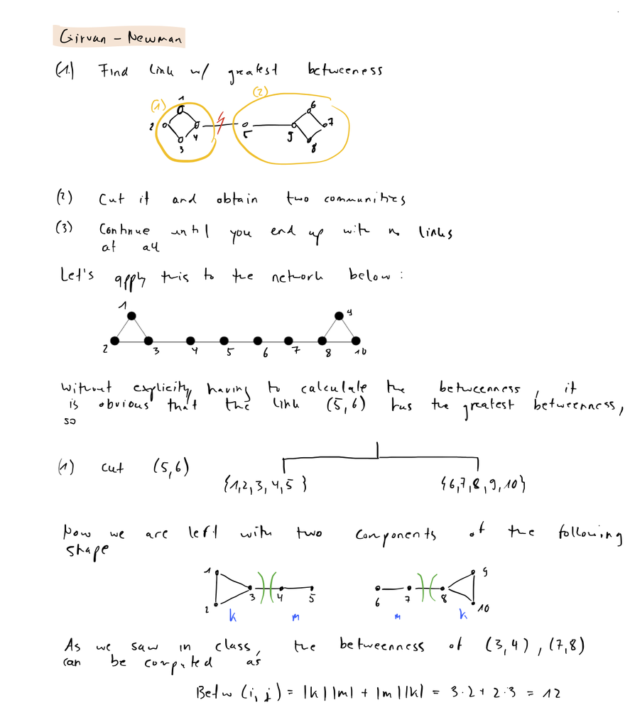

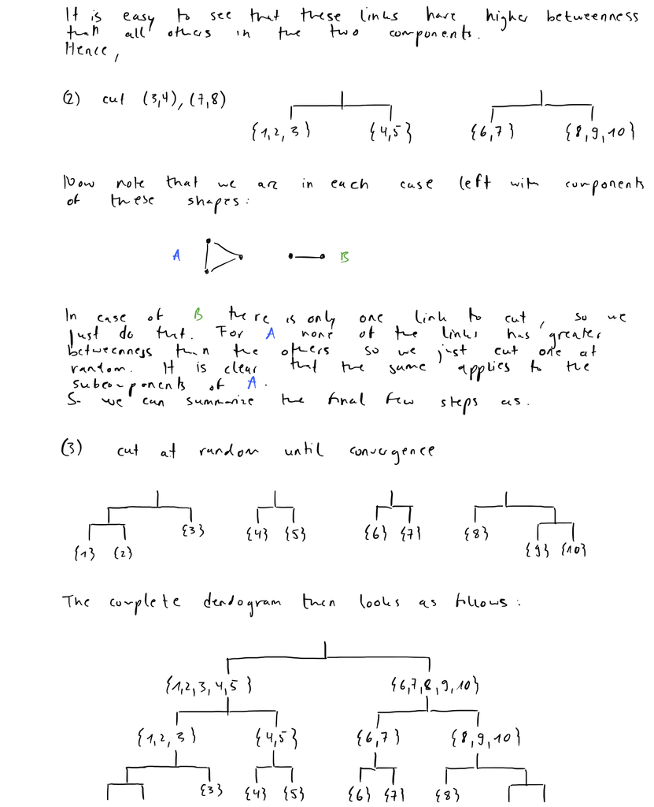

In R we could use `igraph::edge.betweenness.community(g)` to compute the optimal clustering based on modularity directly:

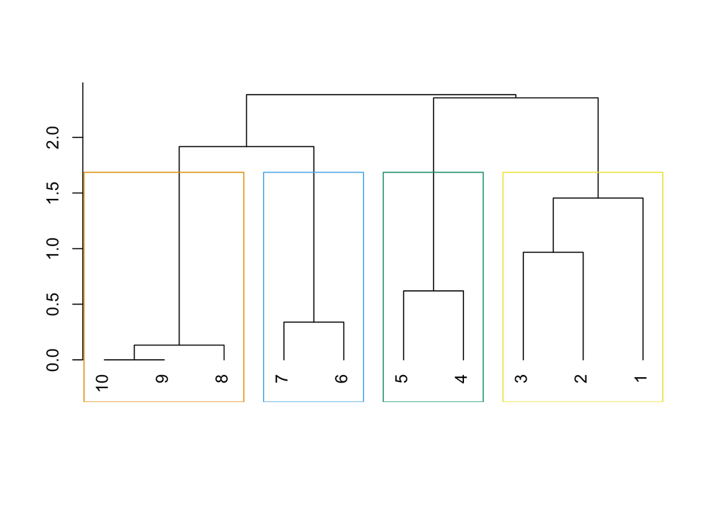

## b)

In R `igraph::edge.betweenness.community(g)` chooses the partition with maximal modularity by default:

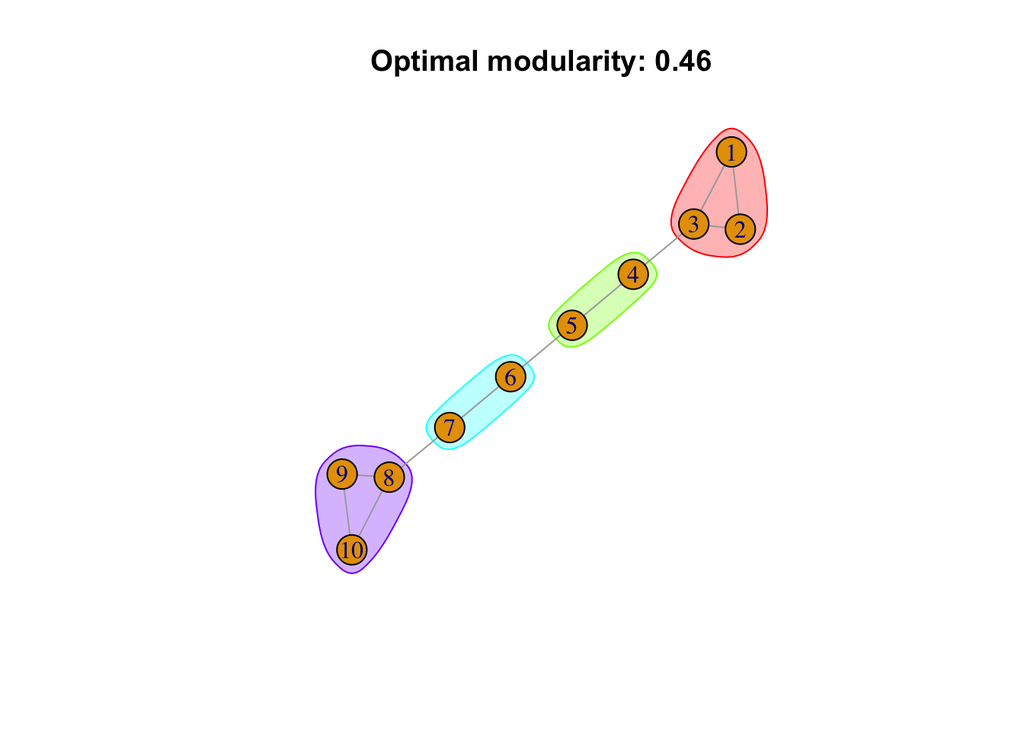

```r
clust <- edge.betweenness.community(g)
plot(g, mark.groups = clust, main=sprintf("Optimal modularity: %0.2f", modularity(g, membership = clust$membership)))
```

Computing the modularity by hand for each layer would be a tedious job, but we can make a few observations that simplify things.

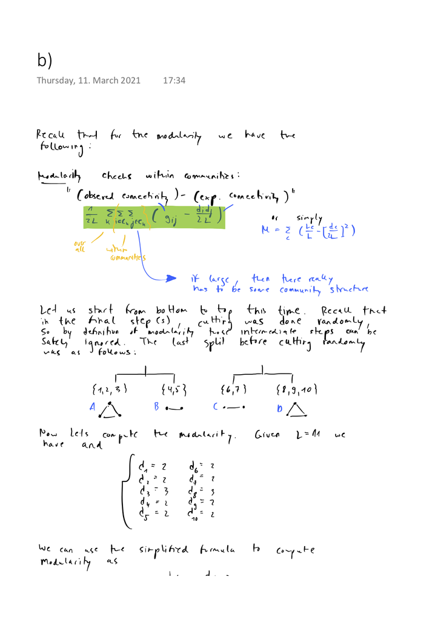

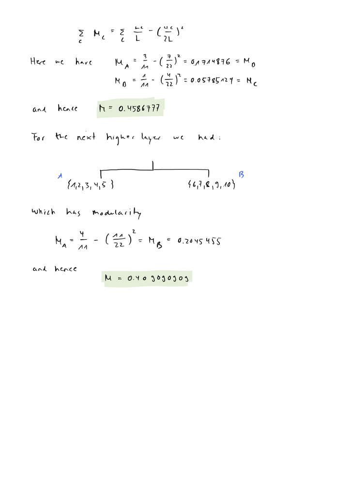

The values correspond to what `igraph` returns. Technically there are a few more intermediate layers we would have to check, but given we have already done this in R and identified the optimal layer, we skip this here (also to avoid repetition).

## c)

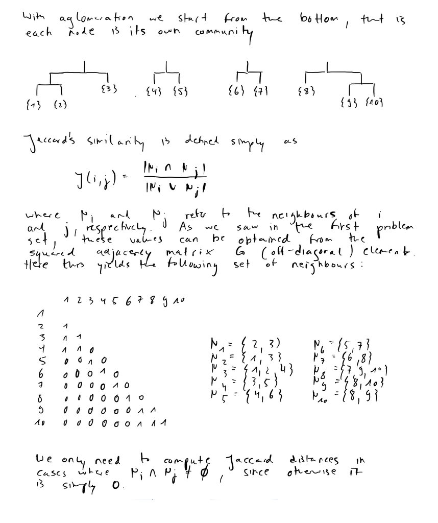

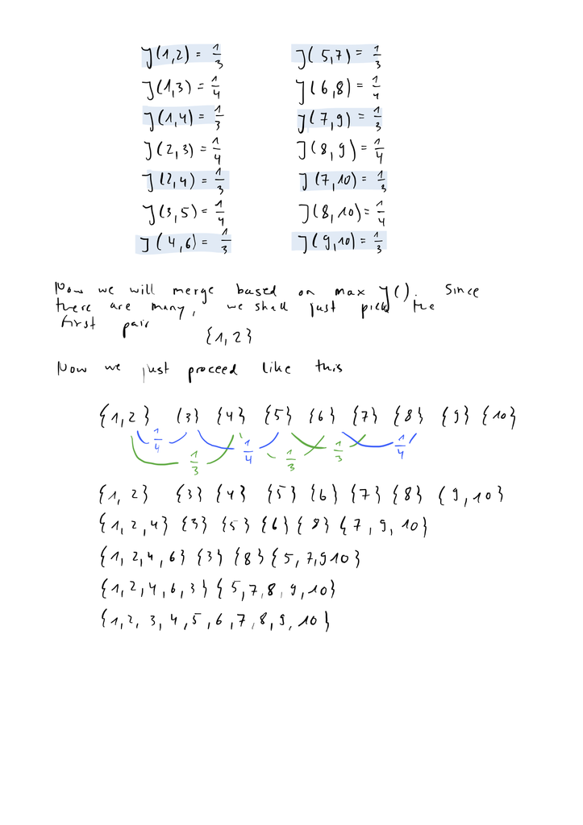

# References

Easley, David, Jon Kleinberg, and others. 2010. *Networks, Crowds, and Markets*. Vol. 8. Cambridge university press Cambridge.